# Optimización de Gestión Hospitalaria

Modelización Predictiva de Estancias Hospitalarias mediante Modelos Estadísticos Avanzados

Yelko Bejarano

# 🎯 Objetivo

Desarrollar modelos predictivos avanzados para optimizar la duración de estancias hospitalarias mediante análisis comparativo entre diferentes metodologías estadísticas (GLM, GAM), identificando los factores clave que determinan el tiempo de hospitalización en una muestra de 2,100 pacientes de múltiples centros hospitalarios.

# 📊 Carga y Preparación de Datos

```r
# Carga de librerías
library(pacman)
p_load(DataExplorer, MASS, lme4, glmmTMB, lmtest, tidyverse, splines,
       DHARMa, Epi, mgcv, visreg, mvoutlier, car,
       knitr, broom, kableExtra, gridExtra)

# Tema personalizado para gráficos
theme_hospital <- function() {
  theme_minimal() +
  theme(
    panel.background = element_rect(fill = "white", color = NA),
    panel.border = element_rect(color = "black", fill = NA, linewidth = 0.5),
    panel.grid.major = element_blank(),
    panel.grid.minor = element_blank(),
    axis.line = element_line(color = "black"),
    axis.ticks = element_line(color = "black"),
    axis.text = element_text(color = "black", size = 9),
    axis.title = element_text(color = "black", size = 10),
    plot.background = element_rect(fill = "white", color = NA),
    plot.title = element_text(hjust = 0.5, face = "bold", size = 12),
    plot.subtitle = element_text(hjust = 0.5, size = 10)
  )
}
```

```r
# Carga de datos
df <- read.table("./data/hospitales.txt", header = TRUE, sep = " ",
                 quote = "\"", stringsAsFactors = FALSE)

# Conversión de variables categóricas
df$Sexo <- as.factor(df$Sexo)
df$Diagnostico <- as.factor(df$Diagnostico)
df$HospitalID <- as.factor(df$HospitalID)

# Resumen estadístico de los datos
datos_resumen <- data.frame(
  Variable = c("Duración Hospitalización", "Edad", "Sexo (F/M)", "Diagnóstico", "Hospital ID"),
  Tipo = c("Continua", "Continua", "Categórica", "Categórica", "Categórica"),
  N_observaciones = c(nrow(df), nrow(df), nrow(df), nrow(df), nrow(df)),
  Descripción = c("Variable respuesta: tiempo de estancia (horas)",
                  "Edad del paciente en años",
                  "Sexo del paciente",
                  "Tipo de diagnóstico (Fractura/Infarto/Neumonía)",
                  "Centro hospitalario (1-10)")
)

kable(datos_resumen,
      caption = "Descripción de variables del estudio") %>%
  kable_styling(bootstrap_options = c("striped", "hover"))
```

Descripción de variables del estudio

| Variable | Tipo | N_observaciones | Descripción |
| --- | --- | --- | --- |
| Duración Hospitalización | Continua | 2100 | Variable respuesta: tiempo de estancia (horas) |
| Edad | Continua | 2100 | Edad del paciente en años |
| Sexo (F/M) | Categórica | 2100 | Sexo del paciente |
| Diagnóstico | Categórica | 2100 | Tipo de diagnóstico (Fractura/Infarto/Neumonía) |
| Hospital ID | Categórica | 2100 | Centro hospitalario (1-10) |

```r
# Estadísticas descriptivas de la duración
cat("Estadísticas de duración hospitalaria:\n")
```

```
## Estadísticas de duración hospitalaria:
```

```r
cat("En horas - Mediana:", round(median(df$DuracionHospitalizacion), 1),
    "| Media:", round(mean(df$DuracionHospitalizacion), 1), "\n")
```

```
## En horas - Mediana: 302.2 | Media: 879.9
```

```r
cat("En días - Mediana:", round(median(df$DuracionHospitalizacion)/24, 1),
    "| Media:", round(mean(df$DuracionHospitalizacion)/24, 1), "\n")
```

```
## En días - Mediana: 12.6 | Media: 36.7
```

**Variables del estudio:**

- **Variable respuesta**: `DuracionHospitalizacion` - Tiempo de estancia hospitalaria (unidades: horas)
- **Predictores clínicos**: Edad (continua), Sexo (F/M), Diagnóstico (Fractura/Infarto/Neumonía)
- **Factor institucional**: HospitalID (10 centros diferentes)

*Nota: Los valores de duración están en horas. Para convertir a días, dividir entre 24.*

# 🔍 Análisis Exploratorio

## Distribución de la Variable Respuesta

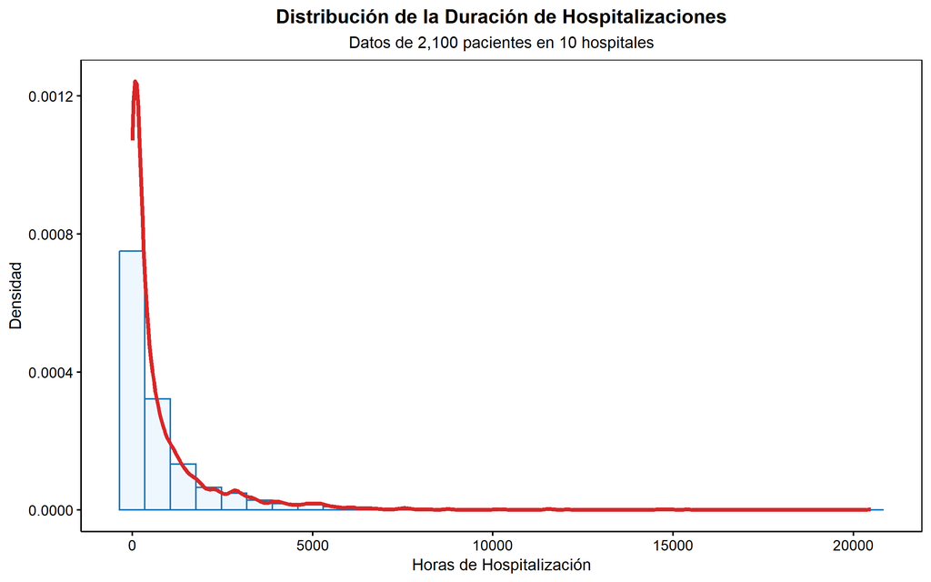

Distribución de la duración de hospitalizaciones

```r
ggplot(df, aes(x = DuracionHospitalizacion)) +
  geom_histogram(aes(y = after_stat(density)), bins = 30,
                 fill = "#E8F4FD", color = "#1f77b4", alpha = 0.7) +
  geom_density(color = "#d62728", linewidth = 1.2) +
  labs(title = "Distribución de la Duración de Hospitalizaciones",
       subtitle = "Datos de 2,100 pacientes en 10 hospitales",
       x = "Horas de Hospitalización",
       y = "Densidad") +
  theme_hospital()
```

La **distribución positiva asimétrica** observada sugiere el uso de una **distribución Gamma** para la modelización, apropiada para variables continuas positivas con sesgo hacia la derecha.

## Análisis por Variables Explicativas

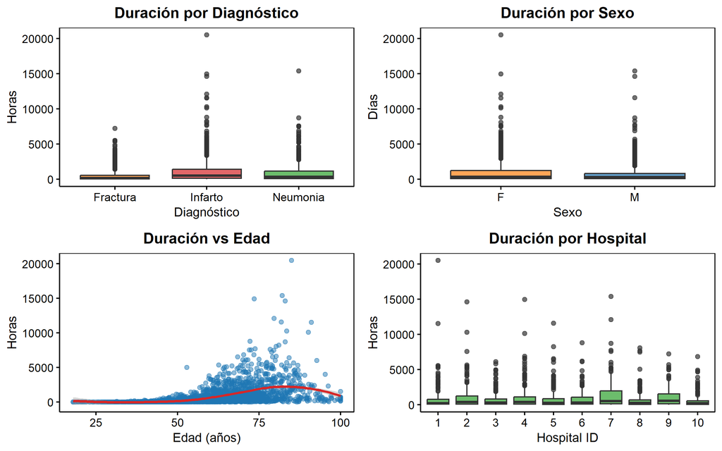

Análisis exploratorio por variables predictoras

```r
# Gráfico por Diagnóstico
p1 <- ggplot(df, aes(x = Diagnostico, y = DuracionHospitalizacion, fill = Diagnostico)) +
  geom_boxplot(alpha = 0.7) +
  scale_fill_manual(values = c("#ff7f0e", "#d62728", "#2ca02c")) +
  labs(title = "Duración por Diagnóstico",
       x = "Diagnóstico", y = "Horas") +
  theme_hospital() +
  theme(legend.position = "none")

# Gráfico por Sexo
p2 <- ggplot(df, aes(x = Sexo, y = DuracionHospitalizacion, fill = Sexo)) +
  geom_boxplot(alpha = 0.7) +
  scale_fill_manual(values = c("#ff7f0e", "#1f77b4")) +
  labs(title = "Duración por Sexo",
       x = "Sexo", y = "Días") +
  theme_hospital() +
  theme(legend.position = "none")

# Gráfico de Edad vs Duración
p3 <- ggplot(df, aes(x = Edad, y = DuracionHospitalizacion)) +
  geom_point(alpha = 0.5, color = "#1f77b4") +
  geom_smooth(method = "loess", color = "#d62728", se = TRUE) +
  labs(title = "Duración vs Edad",
       x = "Edad (años)", y = "Horas") +
  theme_hospital()

# Gráfico por Hospital
p4 <- ggplot(df, aes(x = HospitalID, y = DuracionHospitalizacion)) +
  geom_boxplot(fill = "#2ca02c", alpha = 0.7) +
  labs(title = "Duración por Hospital",
       x = "Hospital ID", y = "Horas") +
  theme_hospital()

grid.arrange(p1, p2, p3, p4, ncol = 2)
```

**Observaciones clave:**

- **Diagnóstico**: Los infartos muestran mayor duración que fracturas y neumonías
- **Sexo**: Diferencias aparentes entre hombres y mujeres
- **Edad**: Relación no lineal (justifica uso de splines)
- **Hospital**: Variabilidad considerable entre centros

# 🔧 Modelización Estadística

## Modelo Lineal Generalizado Inicial

```r
# Modelo GLM inicial con todos los efectos fijos
m1 <- glm(DuracionHospitalizacion ~ Edad + Sexo + Diagnostico + HospitalID,
          family = Gamma(link = "log"),
          data = df)

# Tabla de resultados del modelo inicial
coef_inicial <- summary(m1)$coefficients
tabla_inicial <- data.frame(
  Coeficiente = rownames(coef_inicial),
  Variable = rownames(coef_inicial),
  Estimación = round(coef_inicial[,1], 4),
  Error_Estándar = round(coef_inicial[,2], 4),
  Estadístico_t = round(coef_inicial[,3], 4),
  p_valor = round(coef_inicial[,4], 4),
  Significancia = ifelse(coef_inicial[,4] < 0.001, "***",
                        ifelse(coef_inicial[,4] < 0.01, "**",
                               ifelse(coef_inicial[,4] < 0.05, "*",
                                      ifelse(coef_inicial[,4] < 0.1, ".", ""))))
)

tabla_styled <- kable(tabla_inicial[, c("Coeficiente", "Estimación", "Error_Estándar", "Estadístico_t", "p_valor", "Significancia")],
      col.names = c("Coeficiente", "Estimación", "Error Estándar", "Estadístico t", "p valor", "Significancia"),
      caption = "Modelo GLM Inicial - Todos los efectos fijos") %>%
  kable_styling(bootstrap_options = c("striped", "hover"))

# Aplicar colores según significancia
for(i in 1:nrow(tabla_inicial)) {
  if(tabla_inicial$Significancia[i] == "***") {
    tabla_styled <- tabla_styled %>% row_spec(i, background = "#d4edda")  # Verde claro
  } else if(tabla_inicial$Significancia[i] == "**") {
    tabla_styled <- tabla_styled %>% row_spec(i, background = "#fff3cd")  # Amarillo
  } else if(tabla_inicial$Significancia[i] == "*") {
    tabla_styled <- tabla_styled %>% row_spec(i, background = "#ffeaa7")  # Amarillo claro
  } else if(tabla_inicial$Significancia[i] == ".") {
    tabla_styled <- tabla_styled %>% row_spec(i, background = "#f8f9fa")  # Gris muy claro
  }
}

tabla_styled
```

Modelo GLM Inicial - Todos los efectos fijos

Coeficiente

Estimación

Error Estándar

Estadístico t

p valor

Significancia

(Intercept)

(Intercept)

-0.5810

0.1242

-4.6791

0.0000

***

Edad

Edad

0.1022

0.0016

65.7004

0.0000

***

SexoM

SexoM

-0.3646

0.0457

-7.9813

0.0000

***

DiagnosticoInfarto

DiagnosticoInfarto

0.8811

0.0562

15.6711

0.0000

***

DiagnosticoNeumonia

DiagnosticoNeumonia

0.6498

0.0555

11.7156

0.0000

***

HospitalID2

HospitalID2

0.2564

0.1016

2.5239

0.0117

HospitalID3

HospitalID3

0.0901

0.1033

0.8724

0.3831

HospitalID4

HospitalID4

0.3670

0.1009

3.6364

0.0003

***

HospitalID5

HospitalID5

-0.1291

0.0997

-1.2953

0.1954

HospitalID6

HospitalID6

0.1502

0.0990

1.5178

0.1292

HospitalID7

HospitalID7

0.5673

0.1055

5.3787

0.0000

***

HospitalID8

HospitalID8

-0.1546

0.0997

-1.5504

0.1212

HospitalID9

HospitalID9

0.6593

0.1038

6.3510

0.0000

***

HospitalID10

HospitalID10

-0.1854

0.1018

-1.8214

0.0687

.

```r
cat("AIC del modelo inicial:", round(AIC(m1), 2))
```

```
## AIC del modelo inicial: 29688.91
```

El modelo inicial revela que varios hospitales no son estadísticamente significativos, sugiriendo la necesidad de tratarlos como **efectos aleatorios** para capturar la variabilidad institucional. Además, se puede observar que el objetivo de estos datos no parece ser comparar las diferencias entre hospitales de manera explícita.

## Comparación de Metodologías

```r
# 1. GLM básico sin Hospital
m2 <- glm(DuracionHospitalizacion ~ Edad + Sexo + Diagnostico,
          family = Gamma(link = "log"), data = df)

# 2. GLMER con efectos aleatorios
modgam <- glmer(DuracionHospitalizacion ~ Edad + Sexo + Diagnostico + (1|HospitalID),
                data = df, family = Gamma(link = "log"))

# 3. GLMER con splines en edad
modgamm <- glmer(DuracionHospitalizacion ~ bs(Edad) + Sexo + Diagnostico + (1|HospitalID),
                 data = df, family = Gamma(link = "log"))

# 4. glmmTMB con splines naturales
modgamsm <- glmmTMB(DuracionHospitalizacion ~ ns(Edad) + Sexo + Diagnostico + (1|HospitalID),
                    data = df, family = Gamma(link = "log"))

# 5. GLM con splines naturales y HospitalID fijo
modglmfij <- glm(DuracionHospitalizacion ~ ns(Edad) + Sexo + Diagnostico + HospitalID,
                 data = df, family = Gamma(link = "log"))

# 6. GAM con HospitalID fijo
ajgam <- gam(DuracionHospitalizacion ~ s(Edad) + Sexo + Diagnostico + HospitalID,
             data = df, family = Gamma(link = "log"))

# 7. GAM sin HospitalID
ajgam2 <- gam(DuracionHospitalizacion ~ s(Edad) + Sexo + Diagnostico,
              data = df, family = Gamma(link = "log"))

# 8. GAM con HospitalID como efecto aleatorio
ajgam3 <- gam(DuracionHospitalizacion ~ s(Edad) + Sexo + Diagnostico + s(HospitalID, bs = "re", k = 11),
              data = df, family = Gamma(link = "log"))

# Lista de modelos
modelos <- list(
  GLM_basico = m2,
  GLM_inicial = m1,
  GLMER = modgam,
  GLMER_splines = modgamm,
  glmmTMB = modgamsm,
  GLM_splines = modglmfij,
  GAM_HospFijo = ajgam,
  GAM_sinHosp = ajgam2,
  GAM_HospAlea = ajgam3
)

# Calcular AIC y BIC
comparacion <- data.frame(
  Modelo = names(modelos),
  AIC = sapply(modelos, AIC),
  BIC = sapply(modelos, BIC)
) %>%
  arrange(AIC)

# Tabla de comparación
kable(comparacion,
      digits = 2,
      caption = "Comparación de metodologías - Ordenado por AIC") %>%
  kable_styling(bootstrap_options = c("striped", "hover")) %>%
  row_spec(1, bold = TRUE, color = "white", background = "#28a745")
```

Comparación de metodologías - Ordenado por AIC

|  | Modelo | AIC | BIC |
| --- | --- | --- | --- |
| GAM_HospAlea | GAM_HospAlea | 29251.38 | 29368.11 |
| GAM_HospFijo | GAM_HospFijo | 29251.85 | 29371.67 |
| GLMER_splines | GLMER_splines | 29300.61 | 29351.46 |
| GAM_sinHosp | GAM_sinHosp | 29415.15 | 29485.89 |
| glmmTMB | glmmTMB | 29679.10 | 29718.64 |
| GLM_inicial | GLM_inicial | 29688.91 | 29773.65 |
| GLM_splines | GLM_splines | 29688.91 | 29773.65 |
| GLMER | GLMER | 29713.03 | 29752.58 |
| GLM_basico | GLM_basico | 29823.54 | 29857.44 |

El **modelo GAM con efectos aleatorios hospitalarios** muestra el mejor ajuste (menor AIC), confirmando la importancia de **,odelar la edad de forma no lineal** (splines) y de **capturar la variabilidad hospitalaria** (efectos aleatorios).

## Optimización del Modelo GAM

```r
# Probar diferentes tipos de splines y configuraciones
ajgam3_bs <- gam(DuracionHospitalizacion ~ s(Edad, bs = "bs") + Sexo + Diagnostico + s(HospitalID, bs = "re"),
                 data = df, family = Gamma(link = "log"))

ajgam3_cr <- gam(DuracionHospitalizacion ~ s(Edad, bs = "cr") + Sexo + Diagnostico + s(HospitalID, bs = "re"),
                 data = df, family = Gamma(link = "log"))

ajgam3_tp <- gam(DuracionHospitalizacion ~ s(Edad, bs = "tp") + Sexo + Diagnostico + s(HospitalID, bs = "re"),
                 data = df, family = Gamma(link = "log"))

# Interacción Edad x Sexo
ajgam_int1 <- gam(DuracionHospitalizacion ~ s(Edad, by = Sexo) + Sexo + Diagnostico + s(HospitalID, bs = "re"),
                  data = df, family = Gamma(link = "log"))

# Interacción Edad x Diagnostico
ajgam_int2 <- gam(DuracionHospitalizacion ~ s(Edad, by = Diagnostico) + Sexo + Diagnostico + s(HospitalID, bs = "re"),
                  data = df, family = Gamma(link = "log"))

# Pendiente aleatoria para Edad por Hospital
ajgam_slope <- gam(DuracionHospitalizacion ~ s(Edad) + s(Edad, HospitalID, bs = "re") + Sexo + Diagnostico + s(HospitalID, bs = "re"),
                   data = df, family = Gamma(link = "log"))

# Efectos aleatorios en Diagnóstico
ajgam_diag_random <- gam(DuracionHospitalizacion ~ s(Edad) + Sexo + Diagnostico + s(HospitalID, bs = "re") + s(Diagnostico, bs = "re"),
                         data = df, family = Gamma(link = "log"))

modelos_ext <- list(
  GAM_base = ajgam3,
  GAM_B_splines = ajgam3_bs,
  GAM_cubic_reg = ajgam3_cr,
  GAM_thin_plate = ajgam3_tp,
  GAM_int_sexo = ajgam_int1,
  GAM_int_diag = ajgam_int2,
  GAM_slope_random = ajgam_slope,
  GAM_diag_random = ajgam_diag_random
)

AIC_comp <- sapply(modelos_ext, AIC)
BIC_comp <- sapply(modelos_ext, BIC)

comparacion_ext <- data.frame(
  Modelo = names(modelos_ext),
  AIC = AIC_comp,
  BIC = BIC_comp
) %>%
  arrange(AIC)

kable(comparacion_ext,
      digits = 4,
      caption = "Optimización del modelo GAM - Diferentes configuraciones") %>%
  kable_styling(bootstrap_options = c("striped", "hover")) %>%
  row_spec(0, background = "#f8f9fa", bold = TRUE) %>%
  row_spec(1, bold = TRUE, color = "white", background = "#28a745")
```

Optimización del modelo GAM - Diferentes configuraciones

|  | Modelo | AIC | BIC |
| --- | --- | --- | --- |
| GAM_B_splines | GAM_B_splines | 29251.17 | 29367.03 |
| GAM_slope_random | GAM_slope_random | 29251.38 | 29368.12 |
| GAM_diag_random | GAM_diag_random | 29251.38 | 29368.11 |
| GAM_base | GAM_base | 29251.38 | 29368.11 |
| GAM_thin_plate | GAM_thin_plate | 29251.38 | 29368.11 |
| GAM_cubic_reg | GAM_cubic_reg | 29252.41 | 29367.92 |
| GAM_int_sexo | GAM_int_sexo | 29255.85 | 29405.22 |
| GAM_int_diag | GAM_int_diag | 29266.43 | 29440.42 |

De todas las configuraciones probadas, el modelo con **B-splines** muestra la mejor performance, aunque la mejora es marginal. Esto sugiere que el modelo base ya captura adecuadamente las relaciones en los datos sin necesidar de incluir interacciones o efectos aleatorizados en las pendientes de ninguna variable que puedan afectar a la parsimonia del modelo de forma innecesaria.

# 📈 Modelo Final Seleccionado

```r
# Seleccionar el mejor modelo (B-splines)
modelo_final <- ajgam3_bs

# Resumen del modelo
summary_final <- summary(modelo_final)

# Extraer coeficientes paramétricos
coef_parametricos <- summary_final$p.table
tabla_parametricos <- data.frame(
  Coeficiente = rownames(coef_parametricos),
  Variable = rownames(coef_parametricos),
  Estimación = round(coef_parametricos[,1], 4),
  Error_Estándar = round(coef_parametricos[,2], 4),
  Estadístico_t = round(coef_parametricos[,3], 4),
  p_valor = round(coef_parametricos[,4], 4),
  Significancia = ifelse(coef_parametricos[,4] < 0.001, "***",
                        ifelse(coef_parametricos[,4] < 0.01, "**",
                               ifelse(coef_parametricos[,4] < 0.05, "*",
                                      ifelse(coef_parametricos[,4] < 0.1, ".", ""))))
)

# Extraer términos suavizados
terminos_suaves <- summary_final$s.table
tabla_suaves <- data.frame(
  Término = rownames(terminos_suaves),
  Variable = rownames(terminos_suaves),
  edf = round(terminos_suaves[,1], 4),
  Ref_df = round(terminos_suaves[,2], 4),
  Estadístico_F = round(terminos_suaves[,3], 4),
  p_valor = round(terminos_suaves[,4], 4),
  Significancia = ifelse(terminos_suaves[,4] < 0.001, "***",
                        ifelse(terminos_suaves[,4] < 0.01, "**",
                               ifelse(terminos_suaves[,4] < 0.05, "*",
                                      ifelse(terminos_suaves[,4] < 0.1, ".", ""))))
)

# Tabla de coeficientes paramétricos con colores por significancia
tabla_param_styled <- kable(tabla_parametricos[, c("Coeficiente", "Estimación", "Error_Estándar", "Estadístico_t", "p_valor", "Significancia")],
      caption = "Coeficientes paramétricos del modelo GAM final",
      col.names = c("Coeficiente", "Estimación", "Error Estándar", "Estadístico t", "p valor", "Significancia")) %>%
  kable_styling(bootstrap_options = c("striped", "hover"))

for(i in 1:nrow(tabla_parametricos)) {
  if(tabla_parametricos$Significancia[i] == "***") {
    tabla_param_styled <- tabla_param_styled %>% row_spec(i, background = "#d4edda")
  } else if(tabla_parametricos$Significancia[i] == "**") {
    tabla_param_styled <- tabla_param_styled %>% row_spec(i, background = "#fff3cd")
  } else if(tabla_parametricos$Significancia[i] == "*") {
    tabla_param_styled <- tabla_param_styled %>% row_spec(i, background = "#ffeaa7")
  } else if(tabla_parametricos$Significancia[i] == ".") {
    tabla_param_styled <- tabla_param_styled %>% row_spec(i, background = "#f8f9fa")
  }
}

tabla_param_styled
```

Coeficientes paramétricos del modelo GAM final

|  | Coeficiente | Estimación | Error Estándar | Estadístico t | p valor | Significancia |
| --- | --- | --- | --- | --- | --- | --- |
| (Intercept) | (Intercept) | 5.6496 | 0.0946 | 59.7269 | 0 | *** |
| SexoM | SexoM | -0.3560 | 0.0419 | -8.4969 | 0 | *** |
| DiagnosticoInfarto | DiagnosticoInfarto | 0.8904 | 0.0515 | 17.3053 | 0 | *** |
| DiagnosticoNeumonia | DiagnosticoNeumonia | 0.6315 | 0.0508 | 12.4332 | 0 | *** |

```r
# Tabla de términos suavizados con colores por significancia
tabla_suaves_styled <- kable(tabla_suaves[, c("Término", "edf", "Ref_df", "Estadístico_F", "p_valor", "Significancia")],
      caption = "Términos suavizados del modelo GAM final",
      col.names = c("Término", "edf", "Ref.df", "Estadístico F", "p valor", "Significancia")) %>%
  kable_styling(bootstrap_options = c("striped", "hover"))

for(i in 1:nrow(tabla_suaves)) {
  if(tabla_suaves$Significancia[i] == "***") {
    tabla_suaves_styled <- tabla_suaves_styled %>% row_spec(i, background = "#d4edda")
  } else if(tabla_suaves$Significancia[i] == "**") {
    tabla_suaves_styled <- tabla_suaves_styled %>% row_spec(i, background = "#fff3cd")
  } else if(tabla_suaves$Significancia[i] == "*") {
    tabla_suaves_styled <- tabla_suaves_styled %>% row_spec(i, background = "#ffeaa7")
  } else if(tabla_suaves$Significancia[i] == ".") {
    tabla_suaves_styled <- tabla_suaves_styled %>% row_spec(i, background = "#f8f9fa")
  }
}

tabla_suaves_styled
```

Términos suavizados del modelo GAM final

|  | Término | edf | Ref.df | Estadístico F | p valor | Significancia |
| --- | --- | --- | --- | --- | --- | --- |
| s(Edad) | s(Edad) | 7.0245 | 7.6082 | 693.066 | 0 | *** |
| s(HospitalID) | s(HospitalID) | 8.4826 | 9.0000 | 18.707 | 0 | *** |

**Modelo final:**
$$Y_i \sim
\text{Gamma}(\mu_i, \phi), \quad i = 1,\ldots,2100$$
$$\log(\mu_i) = \beta_0 + f(\text{Edad}_i) +
\beta_1 \text{Sexo}(M)_i + \beta_2 \text{Diagnóstico}(\text{Infarto})_i
+ \beta_3 \text{Diagnóstico}(\text{Neumonía})_i + u_{j[i]}$$

Donde $f(\text{Edad}_i)$ es una función suavizada B-spline y $u_{j[i]} \sim N(0, \sigma_u^2)$ representa efectos aleatorios hospitalarios.

**Resultados clave:**

- **R² ajustado**: 0.3618 (36.2% de variabilidad explicada)
- **Deviance explicada**: 60.7% (excelente para datos clínicos)
- **Todos los efectos significativos**: p < 0.05 para variables principales

## Visualización del Modelo Final

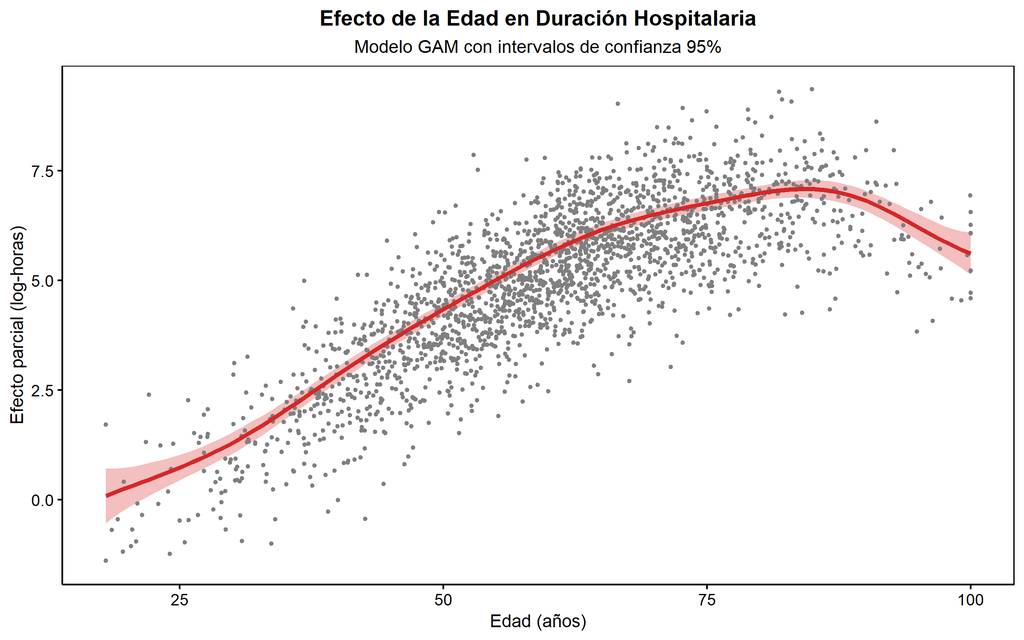

Efectos del modelo GAM final

```r
# Gráfico de efectos suavizados
visreg(modelo_final, "Edad",
       gg = TRUE,  # Usa ggplot2
       line = list(col = "#d62728", size = 1.2),
       fill = list(fill = "#d62728", alpha = 0.3)) +
  labs(title = "Efecto de la Edad en Duración Hospitalaria",
       subtitle = "Modelo GAM con intervalos de confianza 95%",
       x = "Edad (años)",
       y = "Efecto parcial (log-horas)") +
  theme_hospital()
```

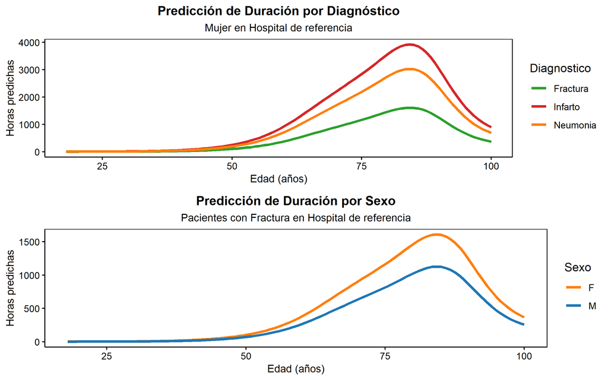

Interpretación de efectos por variable

```r
# Efectos por diagnóstico
pred_data <- expand.grid(
  Edad = seq(min(df$Edad), max(df$Edad), length.out = 100),
  Sexo = "F",
  Diagnostico = c("Fractura", "Infarto", "Neumonia"),
  HospitalID = "1"
)

pred_data$prediccion <- predict(modelo_final, pred_data, type = "response")

p_diag <- ggplot(pred_data, aes(x = Edad, y = prediccion, color = Diagnostico)) +
  geom_line(linewidth = 1.2) +
  scale_color_manual(values = c("#2ca02c", "#d62728", "#ff7f0e")) +
  labs(title = "Predicción de Duración por Diagnóstico",
       subtitle = "Mujer en Hospital de referencia",
       x = "Edad (años)", y = "Horas predichas") +
  theme_hospital()

# Efectos por sexo
pred_sexo <- expand.grid(
  Edad = seq(min(df$Edad), max(df$Edad), length.out = 100),
  Sexo = c("F", "M"),
  Diagnostico = "Fractura",
  HospitalID = "1"
)

pred_sexo$prediccion <- predict(modelo_final, pred_sexo, type = "response")

p_sexo <- ggplot(pred_sexo, aes(x = Edad, y = prediccion, color = Sexo)) +
  geom_line(linewidth = 1.2) +
  scale_color_manual(values = c("#ff7f0e", "#1f77b4")) +
  labs(title = "Predicción de Duración por Sexo",
       subtitle = "Pacientes con Fractura en Hospital de referencia",
       x = "Edad (años)", y = "Horas predichas") +
  theme_hospital()

grid.arrange(p_diag, p_sexo, ncol = 1)
```